# 03 curbage_recognition Figures

### Angelique I. Delarazan

#### 04/19/2022

Generates figures for the curbage paper:

1. Swamplots of two-way ANOVAs on target recognition and lure (2 x 2 ANOVA: Domain Type [Narrarive v. Perceptual] x Age [Older v. Younger])
2. Swamplots of two-way ANOVAs on target recognition and lure (2 x 2 ANOVA: Domain Type [Narrarive v. Perceptual] x Age [Older v. Younger]) after split on MoCA among older adult sample
3. Legend

Export figures as 800 x 800 or larger.

Note: Data cleaning completed using Python (see jupyter notebook: 01_curbage_recognition_data_cleaning.ipynb) and analyses conducted using R (see 02_curbage_recognition_analyses.Rmd)

### Set Up

```r
#Import Libraries
library(tidyverse)
library(ggplot2)
library(ggsignif)
library(ggpubr)
library(dplyr)
library(ggbeeswarm)
```

```r
recognition = read_csv("/Volumes/GAMMA/curbage_recognition/data/sub-all_group-all_task-recognition_desc-all_results_neuropsych.csv")
recognition$subject = as.numeric(recognition$subject)
recognition$group = as.factor(recognition$group)
recognition$type = as.factor(recognition$type)
recognition$LDI = as.numeric(recognition$LDI)
recognition$group_type = as.factor(recognition$group_type)
recognition$dprime = as.numeric(recognition$dprime)
```

### Figure 2a. Swarmplot of dprime for all subjects. Save out as: 8400 (W) X 4200 (H)

```r
#dprime

#dprime_all =
  recognition %>%
  ggplot(aes(x = type, group = group, y = dprime, col = group)) +
  ylab("Target Recognition (d')
       ") + xlab("Test Domain") + labs(title = "") +
  coord_cartesian(ylim = c(0.8, 5.5)) +
  geom_beeswarm(dodge.width = 1, size = 5, alpha = 0.7) +
  stat_summary(fun = mean, na.rm = TRUE,
               geom = "point",
               size = 3, color = "black",
               position = position_dodge(width = 1)) +
  stat_summary(fun.data = mean_cl_normal, na.rm = TRUE,
               geom = "errorbar", width = 0.2, color = "black",
               position = position_dodge(width = 1),
               size = 1) +
  scale_color_manual("group",values = c("older"="#da7b5e","younger"="#5d747c"), labels = c("older"="Older","younger"="Younger")) +
  theme(legend.position = "none",
        plot.title = element_text(size = 48),
        axis.text.y = element_text(size = 32),
        axis.text.x = element_text(size = 32),
        axis.title = element_text(size = 32),
        legend.text=element_text(size=24),
        legend.title = element_blank())+
  scale_x_discrete(labels=c("narrative"="Narrative", "perceptual"="Perceptual"))  +
  geom_signif(y_position = c(5),
            xmin = c(1), xmax = c(2),
            size = 1,
            annotation = c("**"), tip_length = 0, textsize = 12, color = "black") +
  scale_y_continuous(breaks=c(1.0,2.0,3.0,4.0,5.0), labels = scales::number_format(accuracy = 0.1))
```

### Figure 2b. Swarmplot of LDI for all subjects.

```r
#LDI

#LDI_all =
  recognition %>%
  group_by(subject) %>%
  ggplot(aes(x = type, group = group, y = LDI, col = group)) +
  ylab("Lure Discrimination (LDI)
       ") + xlab("Test Domain") + labs(title = "") +
  coord_cartesian(ylim = c(-.1, 1.3)) +
  geom_beeswarm(dodge.width = 1, size = 5, alpha = 0.7) +
  stat_summary(fun = mean, na.rm = TRUE,
               geom = "point",
               size = 3, color = "black",
               position = position_dodge(width = 1)) +
  stat_summary(fun.data = mean_se, na.rm = TRUE,
               geom = "errorbar", width = 0.2, color = "black",
               position = position_dodge(width = 1),
               size = 1) +
  scale_color_manual("group",values = c("older"="#da7b5e","younger"="#5d747c"), labels = c("older"="Older","younger"="Younger")) +
  geom_signif(y_position = c(1.2, 1.0),
            xmin = c(1,1.8), xmax = c(2,2.2),
            size = 1,
            annotation = c("***","**"), tip_length = 0, textsize = 12, color = "black") +
  theme(legend.position = "none",
        plot.title = element_text(size = 48),
        axis.text.y = element_text(size = 32),
        axis.text.x = element_text(size = 32),
        axis.title = element_text(size = 32),
        legend.text=element_text(size=24),
        legend.title = element_blank())+
  scale_x_discrete(labels=c("narrative"="Narrative", "perceptual"="Perceptual"))
  #scale_y_continuous(breaks=c(0.0,0.5,1.0))
```

### Split on MOCA

MoCA scores range from 0-30, and a score of 26 or higher is generally considered as “normal.” Given that our older adult sample exhibited heterogeneity in falling above or below a MoCA score of 26, we incorporated a simple contrast of cognitive ability in our analyses via split based on MoCA score. Older participants were categorized in two groups: Lower MoCA Scores (MoCA score < 26) and Higher MoCA Scores (MoCA score >= 26).

#### Subset dataframe to low and high MoCA scorers

```r
younger = filter(recognition, group=="younger")
older_low_MoCA = filter(recognition, MoCA_total<26)
older_high_MoCA = filter(recognition, MoCA_total>25)
low_MoCA = rbind(younger, older_low_MoCA)
high_MoCA = rbind(younger, older_high_MoCA)
```

### Figure 3a. Swarmplot of d’ for low MoCA scorers.

```r
dprime_low =
  low_MoCA%>%
  ggplot(aes(x = type, group = group, y = dprime, col = group))  +
  ylab("Target Recognition (d')
       ") + xlab("Test Domain") + labs(title = "", subtitle = expression("Younger vs. Older"[italic("(Low MoCA Scorer)")])) +
  coord_cartesian(ylim = c(0.8, 5.5)) +
  geom_beeswarm(dodge.width = 1, size = 5, alpha = 0.7) +
  stat_summary(fun = mean, na.rm = TRUE,
               geom = "point",
               size = 3, color = "black",
               position = position_dodge(width = 1)) +
  stat_summary(fun.data = mean_se, na.rm = TRUE,
               geom = "errorbar", width = 0.2, color = "black",
               position = position_dodge(width = 1),
               size = 1) +
  scale_color_manual("group",values = c("older"="#da7b5e","younger"="#5d747c"), labels = c("older"="Older","younger"="Younger")) +
#  geom_signif(y_position = c(5.1),
#            xmin = c(1.3), xmax = c(2.2),
#            size = 1,
#            annotation = c("***"), tip_length = 0, textsize = 12, color = "black") +
  theme(legend.position = "none",
        plot.title = element_text(size = 48),
        axis.text.y = element_text(size = 32),
        axis.text.x = element_text(size = 32),
        axis.title = element_text(size = 32),
        legend.text=element_text(size=24),
        legend.title = element_blank(),
        plot.subtitle = element_text(hjust=0.5, size = 30, color = 'grey28'),
        )+
  scale_x_discrete(labels=c("narrative"="Narrative", "perceptual"="Perceptual"))  +
  scale_y_continuous(breaks=c(1.0,2.0,3.0,4.0, 5.0), labels = scales::number_format(accuracy = 0.1))

dprime_low
```

### Figure 3b. Swarmplot of d’ for high MoCA scorers.

```r
dprime_high =
  high_MoCA%>%
  ggplot(aes(x = type, group = group, y = dprime, col = group))  +
  ylab("Target Recognition (d')
       ") + xlab("Test Domain") + labs(title = "", subtitle = expression("Younger vs. Older"[italic("(High MoCA Scorer)")])) +
  coord_cartesian(ylim = c(0.8, 5.5)) +
  geom_beeswarm(dodge.width = 1, size = 5, alpha = 0.7) +
  stat_summary(fun = mean, na.rm = TRUE,
               geom = "point",
               size = 3, color = "black",
               position = position_dodge(width = 1)) +
  stat_summary(fun.data = mean_se, na.rm = TRUE,
               geom = "errorbar", width = 0.2, color = "black",
               position = position_dodge(width = 1),
               size = 1) +
  scale_color_manual("group",values = c("older"="#da7b5e","younger"="#5d747c"), labels = c("older"="Older","younger"="Younger")) +
  geom_signif(y_position = c(4.5,5.1),
            xmin = c(0.8,1.3), xmax = c(1.7,2.2),
            size = 1,
            annotation = c("***","***"), tip_length = 0, textsize = 12, color = "black") +
  theme(legend.position = "none",
        plot.title = element_text(size = 48),
        axis.text.y = element_text(size = 32),
        axis.text.x = element_text(size = 32),
        axis.title = element_text(size = 32),
        legend.text=element_text(size=24),
        legend.title = element_blank(),
        plot.subtitle = element_text(hjust=0.5, size = 30, color = 'grey28'),
        )+
  scale_x_discrete(labels=c("narrative"="Narrative", "perceptual"="Perceptual"))  +
  scale_y_continuous(breaks=c(1.0,2.0,3.0,4.0, 5.0), labels = scales::number_format(accuracy = 0.1))

dprime_high
```

### Figure 3c. Swarmplot of LDI for low MoCA scorers.

```r
LDI_low =
  low_MoCA %>%
  ggplot(aes(x = type, group = group, y = LDI, col = group))  +
  ylab("Lure Discrimination (LDI)
       ") + xlab("Test Domain") + labs(title = "", subtitle = expression("Younger vs. Older"[italic("(Low MoCA Scorer)")])) +
  coord_cartesian(ylim = c(-.1, 1.2)) +
  geom_beeswarm(dodge.width = 1, size = 5, alpha = 0.7) +
  stat_summary(fun = mean, na.rm = TRUE,
               geom = "point",
               size = 3, color = "black",
               position = position_dodge(width = 1)) +
  stat_summary(fun.data = mean_se, na.rm = TRUE,
               geom = "errorbar", width = 0.2, color = "black",
               position = position_dodge(width = 1),
               size = 1) +
  scale_color_manual("group",values = c("older"="#da7b5e","younger"="#5d747c"), labels = c("older"="Older","younger"="Younger")) +
  geom_signif(y_position = c(1.1, 1),
            xmin = c(0.8,1.8), xmax = c(1.7,2.2),
            size = 1,
            annotation = c("*","**"), tip_length = 0, textsize = 12, color = "black") +
  theme(legend.position = "none",
        plot.title = element_text(size = 48),
        axis.text.y = element_text(size = 32),
        axis.text.x = element_text(size = 32),
        axis.title = element_text(size = 32),
        legend.text=element_text(size=24),
        legend.title = element_blank(),
        plot.subtitle = element_text(hjust=0.5, size = 28, color = 'grey28'),
        )+
  scale_x_discrete(labels=c("narrative"="Narrative", "perceptual"="Perceptual"))  +
  scale_y_continuous(breaks=c(0.0,0.5,1.0))

LDI_low
```

```r
LDI_high =
  high_MoCA %>%
  ggplot(aes(x = type, group = group, y = LDI, col = group))   +
  ylab("Lure Discrimination (LDI)
       ") + xlab("Test Domain") + labs(title = "", subtitle = expression("Younger vs. Older"[italic("(High MoCA Scorer)")])) +
  coord_cartesian(ylim = c(0, 1.3)) +
  geom_beeswarm(dodge.width = 1, size = 5, alpha = 0.7) +
  stat_summary(fun = mean, na.rm = TRUE,
               geom = "point",
               size = 3, color = "black",
               position = position_dodge(width = 1)) +
  stat_summary(fun.data = mean_se, na.rm = TRUE,
               geom = "errorbar", width = 0.2, color = "black",
               position = position_dodge(width = 1),
               size = 1) +
  scale_color_manual("group",values = c("older"="#da7b5e","younger"="#5d747c"), labels = c("older"="Older","younger"="Younger")) +
  geom_signif(y_position = c(1.1, 1.2),
            xmin = c(0.8,1), xmax = c(1.8,2),
            #xmin = c(0.8,1.8), xmax = c(1.7,2.2),
            size = 1,
            annotation = c("*","**"), tip_length = 0, textsize = 12, color = "black") +
  theme(legend.position = "none",
        plot.title = element_text(size = 48),
        axis.text.y = element_text(size = 32),
        axis.text.x = element_text(size = 32),
        axis.title = element_text(size = 32),
        legend.text=element_text(size=24),
        legend.title = element_blank(),
        plot.subtitle = element_text(hjust=0.5, size = 28, color = 'grey28'),
        )+
  scale_x_discrete(labels=c("narrative"="Narrative", "perceptual"="Perceptual")) +
  scale_y_continuous(breaks=c(0.0,0.5,1.0))

LDI_high
```

### 2 x 3 ANOVA

```r
recognition_MoCA$MoCA_condition = factor(recognition_MoCA$MoCA_condition, levels = c("1_low_MoCA", "2_high_MoCA", "3_younger"))
```

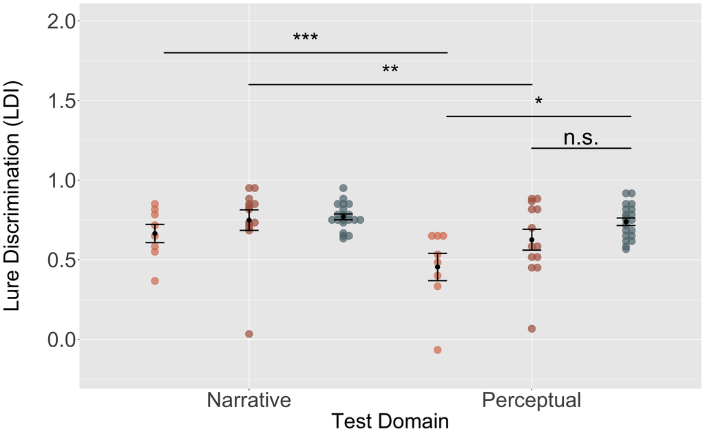

```r
LDI_recognition_MoCA =
  recognition_MoCA %>%
  ggplot(aes(x = type, group = MoCA_condition, y = LDI, col = MoCA_condition))   +
  ylab("Lure Discrimination (LDI)
       ") + xlab("Test Domain") +
  coord_cartesian(ylim = c(-0.2, 2)) +
  geom_beeswarm(dodge.width = 1, size = 5, alpha = 0.7) +
  stat_summary(fun = mean, na.rm = TRUE,
               geom = "point",
               size = 3, color = "black",
               position = position_dodge(width = 1)) +
  stat_summary(fun.data = mean_se, na.rm = TRUE,
               geom = "errorbar", width = 0.2, color = "black",
               position = position_dodge(width = 1),
               size = 1) +
  scale_color_manual("MoCA_condition",
                     values = c("1_low_MoCA_narrative"="#da7b5e",
                                "1_low_MoCA_perceptual"="#da7b5e",
                                "2_high_MoCA_narrative"="#ae624b",
                                "2_high_MoCA_perceptual"="#ae624b",
                                "3_younger_narrative"="#5d747c",
                                "3_younger_perceptual"="#5d747c")) +
                     #labels = c(expression("1_low_MoCA"="Older"[italic("(Low MoCA Scorer)")]), "2_high_MoCA"=expression("Older"[italic("(High MoCA Scorer)")]), "3_younger"="Younger")) +
  geom_signif(y_position = c(1.2, 1.4, 1.6, 1.8),
              #xmin = c(4, 3, 2, 1), xmax = c(6, 6, 5, 4),
              xmin = c(2, 1.7, 1, 0.7), xmax = c(2.35, 2.35, 2, 1.7),
            #xmin = c(0.8,1.8), xmax = c(1.7,2.2),
            size = 1,
            annotation = c("n.s.", "*", "**", "***"), tip_length = 0, textsize = 12, color = "black") +
  theme(legend.position = "none",
        plot.title = element_text(size = 48),
        axis.text.y = element_text(size = 32),
        axis.text.x = element_text(size = 32),
        axis.title = element_text(size = 32),
        legend.text=element_text(size=24),
        legend.title = element_blank(),
        plot.subtitle = element_text(hjust=0.5, size = 28, color = 'grey28'),
        )+
  scale_x_discrete(labels=c("narrative"="Narrative", "perceptual"="Perceptual")) +
  scale_y_continuous(breaks=c(-0.5,0.0,0.5,1.0, 1.5, 2.0))

LDI_recognition_MoCA
```

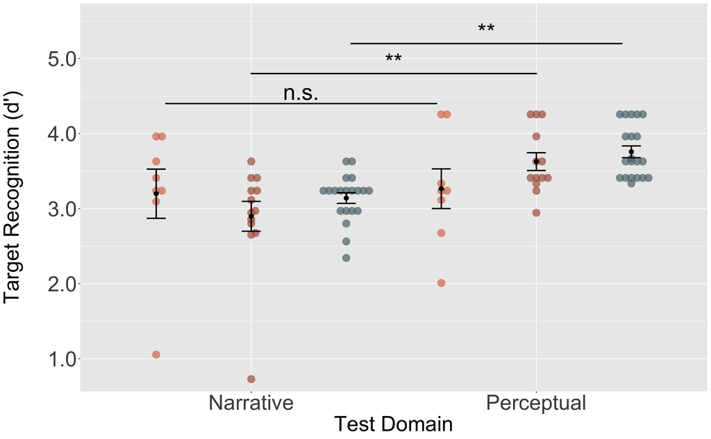

```r
dprime_recognition_MoCA =
  recognition_MoCA %>%
  ggplot(aes(x = type, group = MoCA_condition, y = dprime, col = MoCA_condition))   +
  ylab("Target Recognition (d')
       ") + xlab("Test Domain") +
  coord_cartesian(ylim = c(0.8, 5.5)) +
  geom_beeswarm(dodge.width = 1, size = 5, alpha = 0.7) +
  stat_summary(fun = mean, na.rm = TRUE,
               geom = "point",
               size = 3, color = "black",
               position = position_dodge(width = 1)) +
  stat_summary(fun.data = mean_se, na.rm = TRUE,
               geom = "errorbar", width = 0.2, color = "black",
               position = position_dodge(width = 1),
               size = 1) +
  scale_color_manual("MoCA_condition",
                     values = c("1_low_MoCA_narrative"="#da7b5e",
                                "1_low_MoCA_perceptual"="#da7b5e",
                                "2_high_MoCA_narrative"="#ae624b",
                                "2_high_MoCA_perceptual"="#ae624b",
                                "3_younger_narrative"="#5d747c",
                                "3_younger_perceptual"="#5d747c")) +
  geom_signif(y_position = c(4.4, 4.8, 5.2),
              #xmin = c(4, 3, 2, 1), xmax = c(6, 6, 5, 4),
              xmin = c(0.7, 1, 1.35), xmax = c(1.65, 2, 2.3),
            #xmin = c(0.8,1.8), xmax = c(1.7,2.2),
            size = 1,
            annotation = c("n.s.", "**", "**"), tip_length = 0, textsize = 12, color = "black") +
  theme(legend.position = "none",
        plot.title = element_text(size = 48),
        axis.text.y = element_text(size = 32),
        axis.text.x = element_text(size = 32),
        axis.title = element_text(size = 32),
        legend.text=element_text(size=24),
        legend.title = element_blank(),
        plot.subtitle = element_text(hjust=0.5, size = 28, color = 'grey28'),
        )+
  scale_x_discrete(labels=c("narrative"="Narrative", "perceptual"="Perceptual")) +
  scale_y_continuous(breaks=c(0.0, 1.0,2.0,3.0,4.0,5.0, 6.0), labels = scales::number_format(accuracy = 0.1))

dprime_recognition_MoCA
```

### Recall

```r
recall[(recall$scene!="Either")&(recall$scene!="Integrated")&(recall$subject!=999),] %>%
  drop_na() %>%
  group_by(subject, group, scene) %>%
  mutate(sum = sum(recall_narrative)) %>%
  ungroup() %>%
  group_by(group, scene) %>%
  mutate(mean = mean(sum), se=(sd(sum)/sqrt(20))) %>%
  ungroup() %>%
#  group_by(group) %>%
  ggplot(aes(x=scene, y = mean, group=group, color=group)) +
  labs(x = "Scene",y = "Average Recalled Details",title="")+
  geom_line(aes(color=factor(group)), size=1.5) +
  #geom_path(aes(color=factor(Group)),size=1)+
  #geom_point(aes(color=factor(Group))) +
  geom_errorbar(aes(ymin = mean-se, ymax = mean+se), width=.5,   size=1.5, position=position_dodge(0)) +
  scale_color_manual("Age Group",values = c("older"="#da7b5e","younger"="#5d747c"), labels = c("Older", "Younger")) +
  theme(legend.position = "none",
        plot.title = element_text(size = 48),
        axis.text.y = element_text(size = 32),
        axis.text.x = element_text(size = 32),
        axis.title = element_text(size = 32),
        legend.text=element_text(size=24),
        legend.title = element_blank(),
        plot.subtitle = element_text(hjust=0.5, size = 28, color = 'grey28'),
        )
  #scale_x_discrete(labels=c("A"="Event 1", "B"="Event 2", "C"="Event 3", "D"="Event 4",
  #                          "E"="Event 5", "F"="Event 6", "G"="Event 7", "H"="Event 8",
  #                          "I"="Event 9", "J"="Event 10", "K"="Event 11", "L"="Event 12"))
```

```r
recall[(recall$group!="Transcript")&(recall$scene!="Either")&(recall$subject!=999)&(recall$half!="blah"), ]%>%
  drop_na() %>%
  group_by(subject, group, half) %>%
  mutate(narrative_sum = mean(recall_narrative)) %>%
  ungroup() %>%
  group_by(group, half) %>%
  mutate(narrative_mean = mean(narrative_sum), narrative_se=(sd(narrative_sum)/sqrt(20)))
```

```r
recall[(recall$group!="Transcript")&(recall$scene!="Either")&(recall$subject!=999)&(recall$half!="blah"), ]%>%
  drop_na() %>%
  group_by(subject, group, half) %>%
  mutate(narrative_sum = sum(recall_narrative)) %>%
  ungroup() %>%
  group_by(group, half) %>%
  mutate(narrative_mean = mean(narrative_sum), narrative_se=(sd(narrative_sum)/sqrt(20))) %>%
  ggplot(aes(x= half, y = narrative_mean, fill=group)) +
  geom_bar(stat = "identity", position = "dodge") +
  coord_cartesian(ylim = c(0, 210)) +
  geom_errorbar(aes(ymin = narrative_mean-narrative_se, ymax = narrative_mean+narrative_se), width=0.2, position=position_dodge(0.9)) +
    labs(x ="",y = "Average Recalled Details",title="")+
    scale_x_discrete(labels=c("first_half" = "Early-Story", "second_half" = "Late-Story"))+
    scale_fill_manual("Age Group",values = c("older"="#da7b5e","younger"="#5d747c"), labels = c("Older", "Younger")) +
  geom_signif(y_position=c(200), xmin=c(0.75), xmax=c(1.75), annotation=c("**"), tip_length=0, textsize=10) +
  theme(legend.position = "none",
        plot.title = element_text(size = 48),
        axis.text.y = element_text(size = 32),
        axis.text.x = element_text(size = 32),
        axis.title = element_text(size = 32),
        legend.text=element_text(size=24),
        legend.title = element_blank(),
        plot.subtitle = element_text(hjust=0.5, size = 28, color = 'grey28'),
        )
```

```r
recall[(recall$group!="Transcript")&(recall$scene!="Either")&(recall$subject!=999)&(recall$half!="blah"), ]%>%
  drop_na() %>%
  group_by(subject, group, half) %>%
  mutate(narrative_sum = sum(recall_narrative)) %>%
  ungroup() %>%
  group_by(group) %>%
  mutate(narrative_mean = mean(narrative_sum), narrative_se=(sd(narrative_sum)/sqrt(20))) %>%
  ggplot(aes(x= group, y = narrative_mean, fill=group)) +
  geom_bar(stat = "identity", position = "dodge") +
  coord_cartesian(ylim = c(0, 210)) +
  geom_errorbar(aes(ymin = narrative_mean-narrative_se, ymax = narrative_mean+narrative_se), width=0.2, position=position_dodge(0.9)) +
    labs(x ="Age Group",y = "Average Recalled Details",title="")+
    scale_x_discrete(labels=c("older" = "Older", "younger" = "Younger"))+
    scale_fill_manual("Age Group",values = c("older"="#da7b5e","younger"="#5d747c"), labels = c("Older", "Younger")) +
  geom_signif(y_position=c(200), xmin=c(1), xmax=c(2), annotation=c("n.s."), tip_length=0, textsize=10) +
  theme(legend.position = "none",
        plot.title = element_text(size = 48),
        axis.text.y = element_text(size = 32),
        axis.text.x = element_text(size = 32),
        axis.title = element_text(size = 32),
        legend.text=element_text(size=24),
        legend.title = element_blank(),
        plot.subtitle = element_text(hjust=0.5, size = 28, color = 'grey28'),
        )
```

curbage_fmri

```r
fmri = read_csv("/Users/aidelarazan/Downloads/curbage_fmri_data.csv")

fmri$group = as.factor(fmri$group)
fmri$network = as.factor(fmri$network)
fmri$rval_matched = as.numeric(fmri$rval_matched)
fmri$rval_mismatched = as.numeric(fmri$rval_mismatched)
fmri$sem_ymin = as.numeric(fmri$sem_ymin)
fmri$sem_ymax = as.numeric(fmri$sem_ymax)
```

```r
fmri %>%
  group_by(network, group) %>%
  mutate(difference_score = rval_matched - rval_mismatched) %>%
  ggplot(aes(x= network, y = difference_score, fill=group)) +
  geom_bar(stat = "identity", position = "dodge") +
#  coord_cartesian(ylim = c(0, 210)) +
  geom_errorbar(aes(ymin = difference_score-(sem_ymin/2), ymax = difference_score+(sem_ymax/2)), width=0.2, position=position_dodge(0.9)) +
    labs(x ="",y = "Pattern Similarity \n (Matched - Mismatched)",title="")+
    scale_x_discrete(labels=c("atn" = "AT", "mpn" = "MP",
                              "mtn" = "MTN", "pmn" = "PM"))+
    scale_fill_manual("Age Group",values = c("older"="#da7b5e","younger"="#5d747c"), labels = c("Older", "Younger")) +
  theme(legend.position = "none",
        plot.title = element_text(size = 48),
        axis.text.y = element_text(size = 32),
        axis.text.x = element_text(size = 32),
        axis.title = element_text(size = 32),
        legend.text=element_text(size=24),
        legend.title = element_blank(),
        plot.subtitle = element_text(hjust=0.5, size = 28, color = 'grey28'),
        )
```

```r
fmri %>%
  group_by(network, group) %>%
  mutate(difference_score = rval_matched - rval_mismatched) %>%
  ggplot(aes(x= network, y = difference_score, fill=group)) +
  geom_bar(stat = "identity", position = "dodge") +
#  coord_cartesian(ylim = c(0, 210)) +
  geom_errorbar(aes(ymin = difference_score-(sem_ymin/2), ymax = difference_score+(sem_ymax/2)), width=0.2, position=position_dodge(0.9)) +
    labs(x ="",y = "Pattern Similarity \n (Matched - Mismatched)",title="")+
    scale_x_discrete(labels=c("atn" = "AT", "mpn" = "MP",
                              "mtn" = "MTN", "pmn" = "PM"))+
    scale_fill_manual("Age Group",values = c("older"="#da7b5e","younger"="#5d747c"), labels = c("Older", "Younger")) +
  theme(legend.position = "none",
        plot.title = element_text(size = 48),
        axis.text.y = element_text(size = 32),
        axis.text.x = element_text(size = 32),
        axis.title = element_text(size = 32),
        legend.text=element_text(size=24),
        legend.title = element_blank(),
        plot.subtitle = element_text(hjust=0.5, size = 28, color = 'grey28'),
        )
```

### Generate Legend.

Note: Change + theme(legend.position = " “,… to”right" or “top” to make the legend long or wide format, respectively.

```r
legend = recognition %>%
  ggplot(aes(x = type, group = group, y = LDI, col = group)) +
  ylab("") + xlab("") + labs(title = "", subtitle = "Younger vs. High MoCA Score Older") +
  coord_cartesian(ylim = c(0, 1.10)) +
  geom_beeswarm(dodge.width = 1, size = 5, alpha = 0.8) +
  stat_summary(fun = mean, na.rm = TRUE,
               geom = "point",
               size = 3, color = "black",
               position = position_dodge(width = 1)) +
  stat_summary(fun.data = mean_se, na.rm = TRUE,
               geom = "errorbar", width = 0.2, color = "black",
               position = position_dodge(width = 1),
               size = 1) +
  scale_color_manual("group",values = c("older"="#da7b5e","younger"="#5d747c"), labels = c("older"="Older   ","younger"="Younger")) +
  theme(legend.position = "top",
        plot.title = element_text(size = 48),
        axis.text.y = element_text(size = 32),
        axis.text.x = element_text(size = 32),
        axis.title = element_text(size = 32),
        legend.text=element_text(size=24),
        legend.title = element_blank(),
        plot.subtitle = element_text(hjust=0.5, size = 28, color = 'grey28')
        )+
  scale_x_discrete(labels=c("narrative"="Narrative", "perceptual"="Perceptual"))
  scale_x_discrete(labels=c("narrative"="Narrative", "perceptual"="Perceptual"))

as_ggplot(get_legend(legend))
```

```r
legend_MoCA = recognition_MoCA %>%
  ggplot(aes(x = type, group = MoCA_condition, y = dprime, col = MoCA_condition)) +
  geom_beeswarm(dodge.width = 1, size = 5, alpha = 0.7) +
  scale_color_manual("MoCA_condition",
                     values = c("1_low_MoCA"="#da7b5e", "2_high_MoCA"="#ae624b", "3_younger"="#5d747c"),
                     labels = c(expression("1_low_MoCA"="Older"[italic("(Low MoCA Scorer)")]), "2_high_MoCA"=expression("Older"[italic("(High MoCA Scorer)")]), "3_younger"="Younger")) +
    theme(legend.position = "left",
        plot.title = element_text(size = 48),
        axis.text.y = element_text(size = 32),
        axis.text.x = element_text(size = 32),
        axis.title = element_text(size = 32),
        legend.text=element_text(size=24),
        legend.title = element_blank(),
        plot.subtitle = element_text(hjust=0.5, size = 28, color = 'grey28')
        )+
  scale_x_discrete(labels=c("narrative"="Narrative", "perceptual"="Perceptual"))
  scale_x_discrete(labels=c("narrative"="Narrative", "perceptual"="Perceptual"))
```

[output not shown]

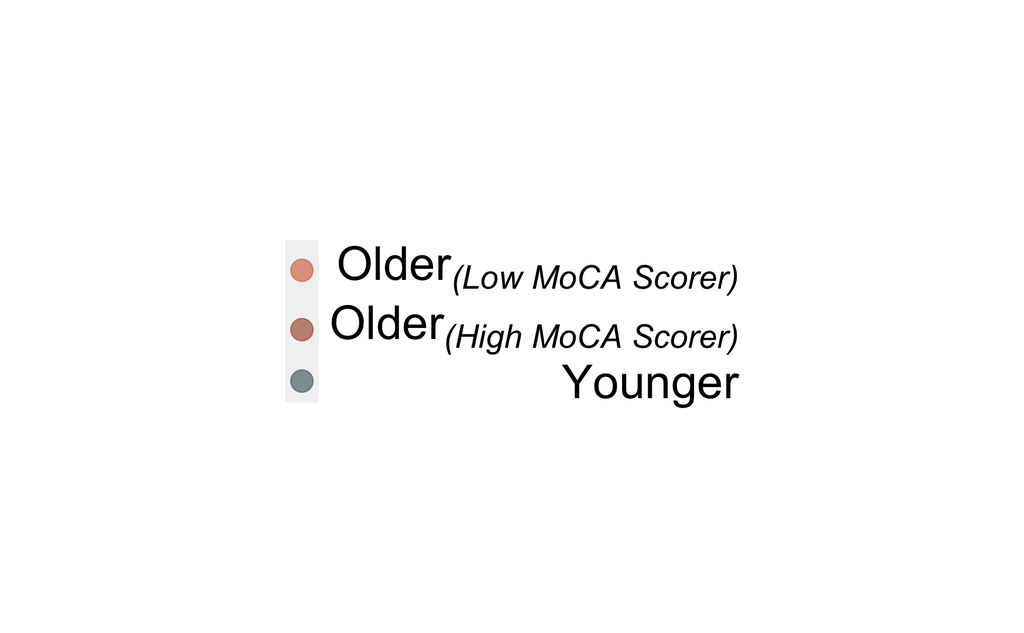

```r
as_ggplot(get_legend(legend_MoCA))
```